# FAIRsimulator: Parallel study

```r
library(FAIRsimulator)
set.seed(32423)
```

# 1 Background

This example will compare two parallel group designs. The first design, the basic design, has 100 subjects per treatment while the alternative design has 200 subjects per treatment arm.

# 2 The basic design

## 2.1 Create the study with the basic design

```r
StudyObjIni <- createStudy(
  nCohorts = 1,
  recruitmentAges = list(c(6,7)*30),
  nSubjects = c(500),
  cohortStartTimes = c(6*30),
  newCohortLink = list(NULL),
  Recruitmentfunction=function(...) {return(5000)},
  samplingDesign = list(seq(0,12,by=2)*30),
  studyStopTime = 18*30+1,
  latestTimeForNewBirthCohorts=6*30,
  treatments =list(c("SoC-1","TRT-1","TRT-2","TRT-3","TRT-4")),
  effSizes = list(c(0.05,0.1,0.15,0.20,0.25)),
  randomizationProbabilities = list(rep(0.20,5))
  )
```

## 2.2 Run the study

The study is simulated with the `AdaptiveStudy` function.

```r
StudyObj <- AdaptiveStudy(StudyObjIni)
```

## 2.3 Visualise the results

### 2.3.1 The number of subjects over time

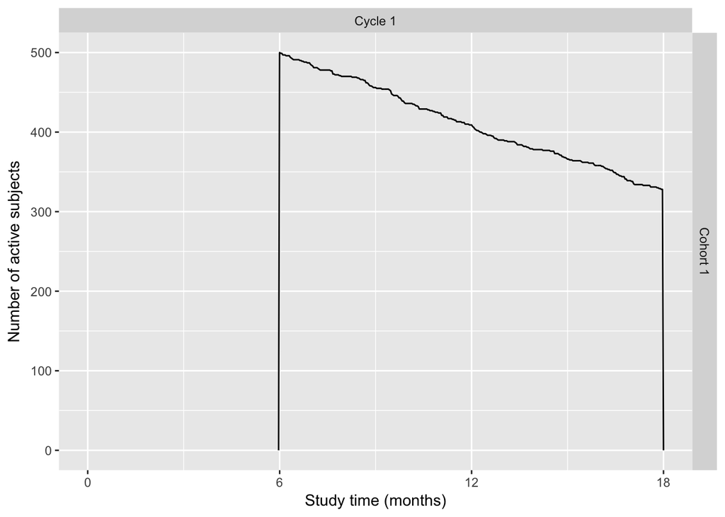

```r
plotActiveSubjects(StudyObj)
```

### 2.3.2 The simulated HAZ data

The simulated HAZ values can be inspected using the `plotHAZ` function.

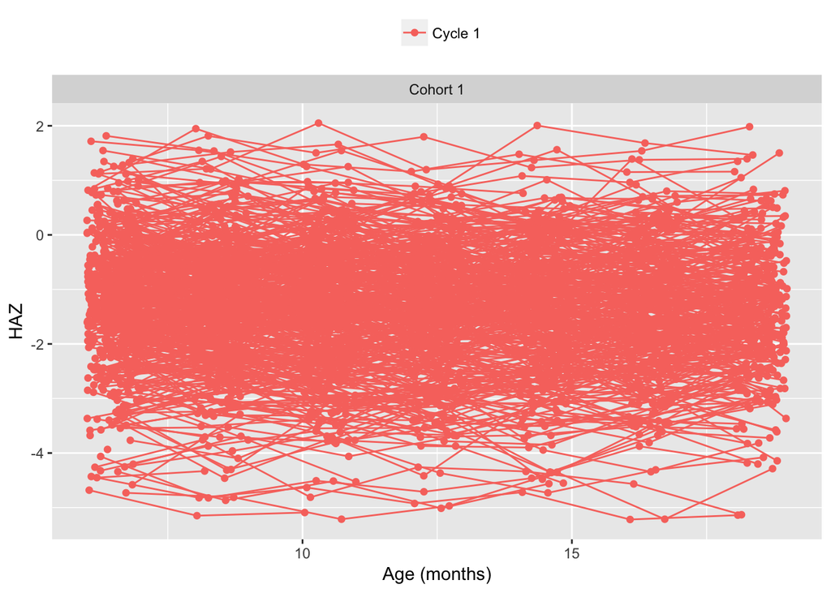

```r
plotHAZ(StudyObj)
```

### 2.3.3 The treatment effects

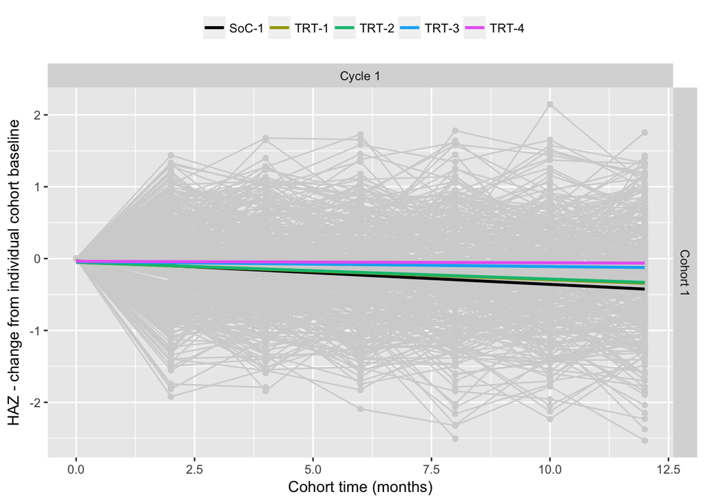

```r
plotHAZTreatmentEff(StudyObj)
```

### 2.3.4 The posterior probabilities

The data can be used to update the posterior probability of the treatments to be better than the other treatments.

```r
tmp <- getProbData(StudyObj,strProb = "UnWeightedUpdateProbabilities",cohortAgeNames="6-18 months")
kable(tmp %>% select(TreatmentName,Prob))
```

| TreatmentName | Prob |
| --- | --- |
| SoC-1 | 0.0012 |
| TRT-1 | 0.0562 |
| TRT-2 | 0.1156 |
| TRT-3 | 0.5326 |
| TRT-4 | 0.2944 |

TRT-3 is surprisingly the treatment with the highest probability of being the best treatment. However, this is based on a single realisation of the design. Running the study many times will allow us to compute statistics on the performance of the design.

## 2.4 Running the basic scenario multiple times to get statistics

The basic scenario is run 100 times to get statistics on the randomization probability updates.

```r
iter   <- 100
ncores <- 7

myMultStud <- runMultiSim(StudyObjIni,iter=iter,ncores=ncores)
```

Extract the probabilities of interest.

```r
probDfUnweightedUpdate <- getMultiProbList(myMultStud[[1]],ncores=ncores, strProb="UnWeightedUpdateProbabilities", cohortAgeNames="6-18 months")
```

Summarise the end of treatment probabilities for plotting and tabulation.

```r
sumData <-
  probDfUnweightedUpdate %>%
  filter(RandStudyTime == max(RandStudyTime)) %>%
  group_by(TreatmentName,CohortAge) %>%
  summarise(
    Mean=mean(Prob),
    Low=quantile(Prob,p=0.025),
    High=quantile(Prob,p=0.975)
    )
```

Plot and tabulate the treatment probability statistics.

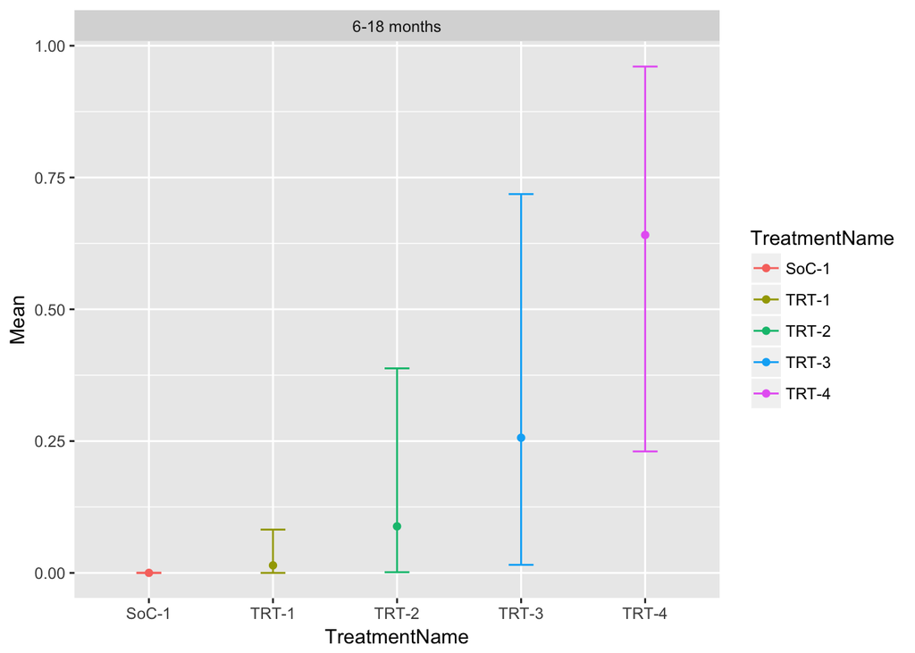

```r
ggplot(sumData,aes(TreatmentName,Mean,color=TreatmentName)) +
  geom_point() +
  geom_errorbar(aes(ymin=Low,ymax=High),width=0.2) +
  facet_wrap(~CohortAge,scales = "free_x")
```

```r
kable(sumData %>% select(TreatmentName,Mean,Low,High) %>% rename(Treatment =TreatmentName,"P0.025"=Low,"P0.975"=High),dig=2)
```

| Treatment | Mean | P0.025 | P0.975 |
| --- | --- | --- | --- |
| SoC-1 | 0.00 | 0.00 | 0.00 |
| TRT-1 | 0.01 | 0.00 | 0.08 |
| TRT-2 | 0.09 | 0.00 | 0.39 |
| TRT-3 | 0.26 | 0.02 | 0.72 |
| TRT-4 | 0.64 | 0.23 | 0.96 |

# 3 The alternative design

```r
set.seed(85859)
```

## 3.1 Create the study with the alternative design

```r
StudyObjIniAlt <- createStudy(
  nCohorts = 1,
  recruitmentAges = list(c(6,7)*30),
  nSubjects = c(1000),
  cohortStartTimes = c(6*30),
  newCohortLink = list(NULL),
  Recruitmentfunction=function(...) {return(5000)},
  samplingDesign = list(seq(0,12,by=2)*30),
  studyStopTime = 18*30+1,
  latestTimeForNewBirthCohorts=6*30,
  treatments =list(c("SoC-1","TRT-1","TRT-2","TRT-3","TRT-4")),
  effSizes = list(c(0.05,0.1,0.15,0.20,0.25)),
  randomizationProbabilities = list(rep(0.20,5))
  )
```

## 3.2 Run the study

Execute the study.

```r
StudyObjAlt <- AdaptiveStudy(StudyObjIniAlt)
```

## 3.3 Visualise the results

### 3.3.1 The number of subjects over time

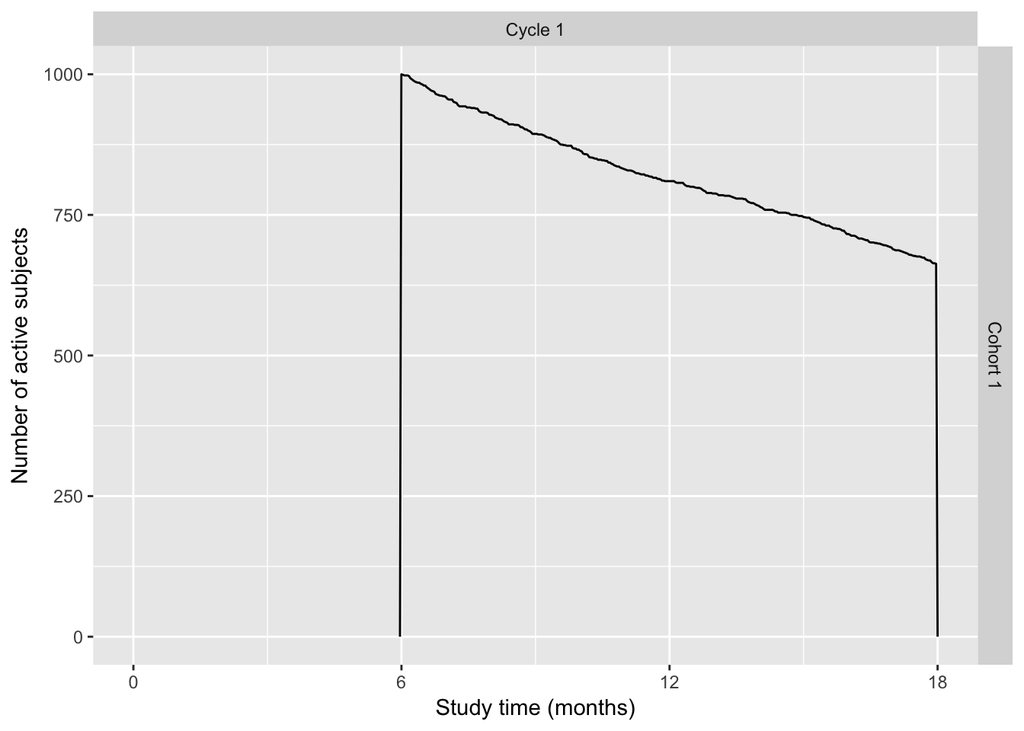

```r
plotActiveSubjects(StudyObjAlt)
```

### 3.3.2 The simulated HAZ data

The simulated HAZ values can be inspected using the `plotHAZ` function.

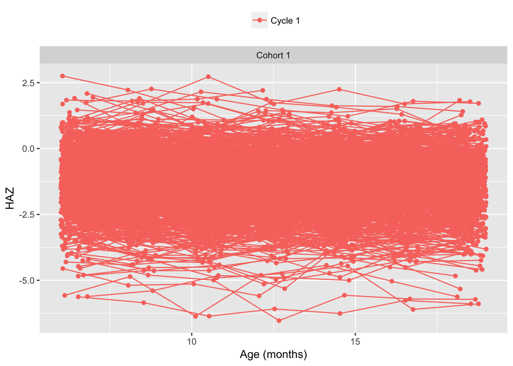

```r
plotHAZ(StudyObjAlt)
```

### 3.3.3 The treatment effects

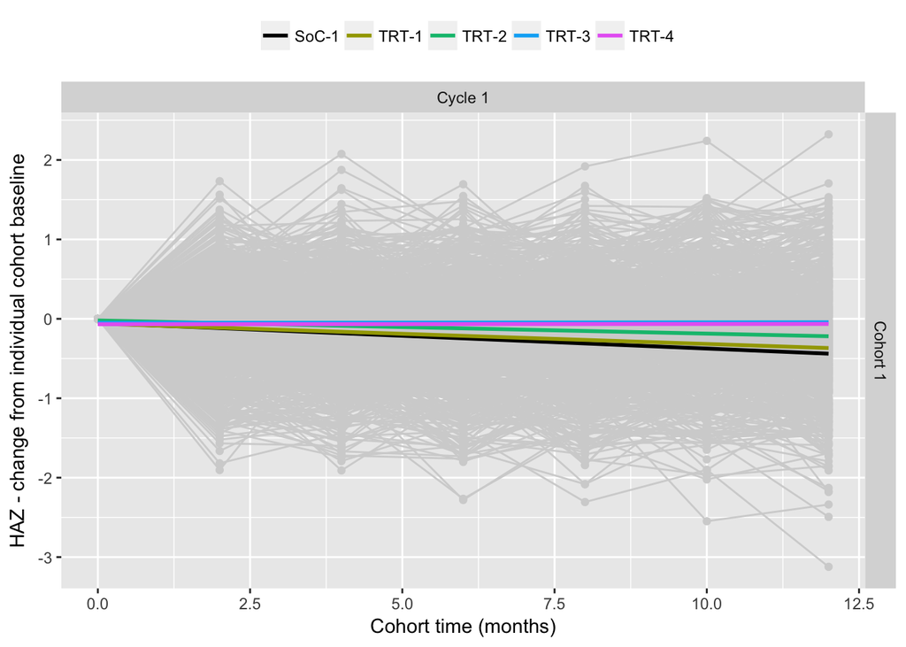

```r
plotHAZTreatmentEff(StudyObjAlt)
```

### 3.3.4 The posterior probabilities

The data can be used to update the posterior probability of the treatments to be better than the other treatments.

```r
tmp <- getProbData(StudyObjAlt,strProb = "UnWeightedUpdateProbabilities",cohortAgeNames="6-18 months")
kable(tmp %>% select(TreatmentName,Prob))
```

| TreatmentName | Prob |
| --- | --- |
| SoC-1 | 0.0000 |
| TRT-1 | 0.0002 |
| TRT-2 | 0.0193 |
| TRT-3 | 0.4163 |
| TRT-4 | 0.5642 |

## 3.4 Running the alternative scenario multiple times to get statistics

The alternative scenario is run 100 times to get statistics on the randomization probability updates.

```r
iter   <- 100
ncores <- 7

myMultStudAlt <- runMultiSim(StudyObjIniAlt,iter=iter,ncores=ncores)
```

Extract the probabilities of interest.

```r
probDfUnweightedUpdateAlt <- getMultiProbList(myMultStudAlt[[1]],ncores=ncores, strProb="UnWeightedUpdateProbabilities", cohortAgeNames="6-18 months")
```

Summarise the end of treatment probabilities for plotting and tabulation.

```r
sumDataAlt <-
  probDfUnweightedUpdateAlt %>%
  filter(RandStudyTime == max(RandStudyTime)) %>%
  group_by(TreatmentName,CohortAge) %>%
  summarise(
    Mean=mean(Prob),
    Low=quantile(Prob,p=0.025),
    High=quantile(Prob,p=0.975)
    )
```

Plot and tabulate the treatment probability statistics.

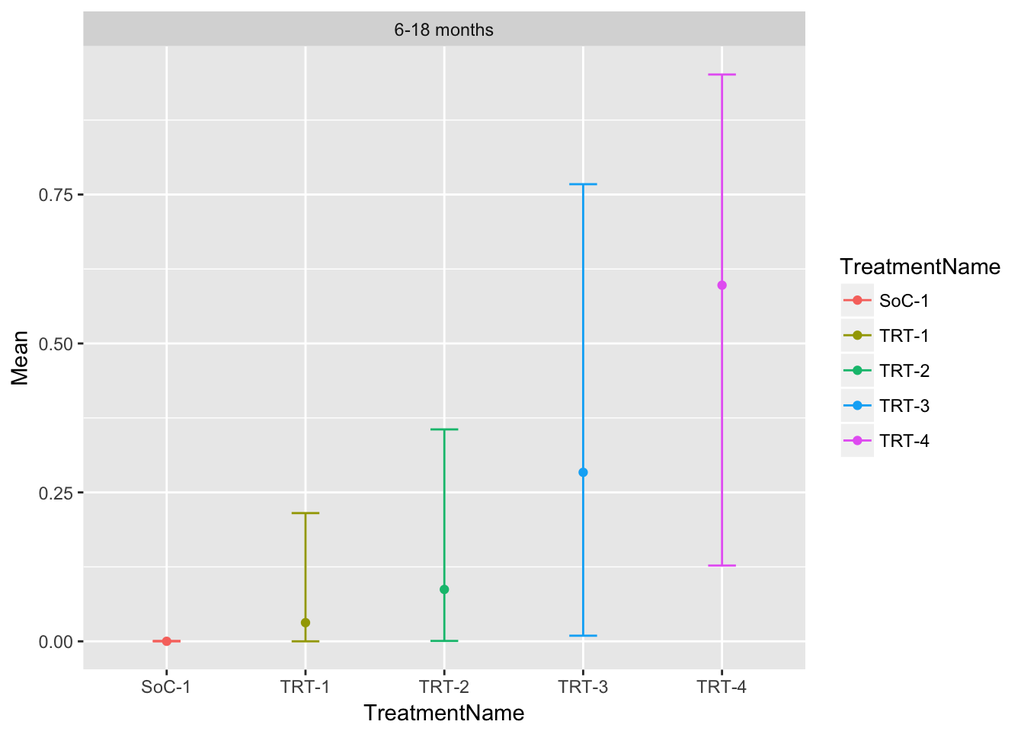

```r
ggplot(sumDataAlt,aes(TreatmentName,Mean,color=TreatmentName)) +
  geom_point() +
  geom_errorbar(aes(ymin=Low,ymax=High),width=0.2) +
  facet_wrap(~CohortAge,scales = "free_x")
```

```r
kable(sumDataAlt %>% select(TreatmentName,Mean,Low,High) %>% rename(Treatment =TreatmentName,"P0.025"=Low,"P0.975"=High),dig=2)
```

| Treatment | Mean | P0.025 | P0.975 |
| --- | --- | --- | --- |
| SoC-1 | 0.00 | 0.00 | 0.00 |
| TRT-1 | 0.03 | 0.00 | 0.22 |
| TRT-2 | 0.09 | 0.00 | 0.36 |
| TRT-3 | 0.28 | 0.01 | 0.77 |
| TRT-4 | 0.60 | 0.13 | 0.95 |